# Problema 2 - Checkpoint 2

## Bilhetes aéreos emitidos para trechos além de BSB

O gráfico abaixo resume como se concentram e estão distribuídos os valores relacionados a emissão de blihetes aéreos com trechos além de BSB (Brasília). Para cada mês, podemos observar suas respectivas distribuições para duas categorias diferentes: quando o passageiro é o próprio parlamentar e quando é uma terceira pessoa. Ao fim da análise o leitor pode concluir que os valores de todos os bilhetes se concentram mais entre 0-1000 reais, a frequência de emissão de bilhetes para parlamentares é maior que para terceiros em todos os meses, pois a macha roxa é maior e mais escura que a laranja e que existem pontos com valores fora do padrão em que, em sua maior parte, foram de bilhetes para parlamentares.

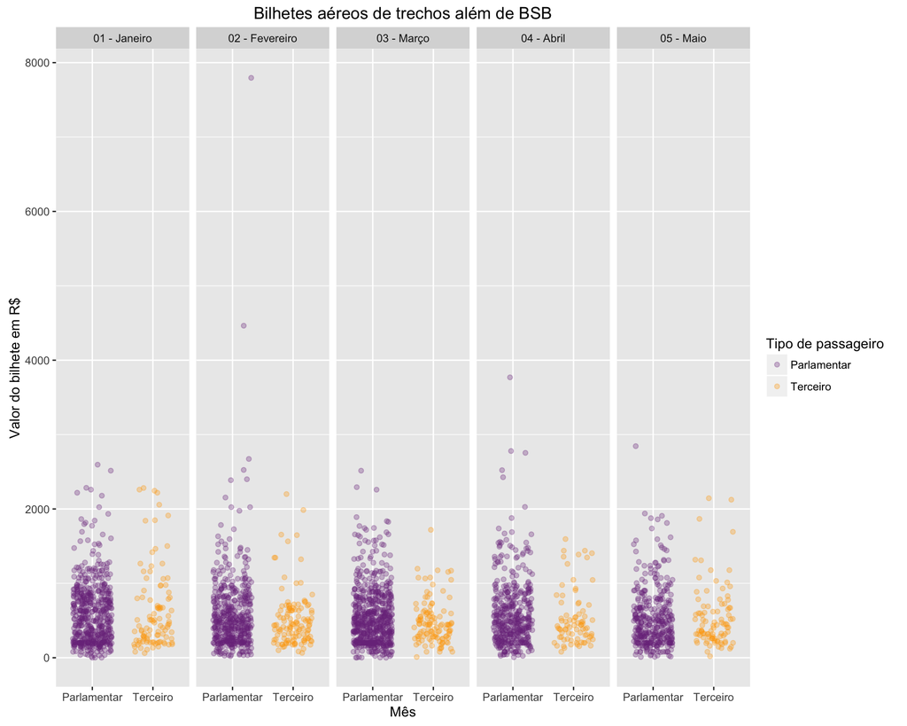

Para facilitar leitura foram feitas algumas mudanças. As categorias de passageiros que antes estavam sobrepostas foram separadas para uma melhor análise individual e comparação. Os valores negativos foram removidos da visualização, o intuito é somente ter valores que foram realmente gastos. Legendas foram adicionadas e uma mudança nas cores foi realizada para melhor compreensão das variáves. O tamanho do gráfico foi aumentado com a intenção de melhorar a visualização já que houve um maior espalhamento dos pontos plotados.